# Unsupervised Machine Learning Techniques - Spice Girls (Tidy Tuesday Week 51 2021)

# The Data

The data is from [week 51 in the Tidy Tuesday 2021 series.](https://github.com/rfordatascience/tidytuesday/blob/master/data/2021/2021-12-14/readme.md) Lets take a quick look at the data:

```r
glimpse(studio_album_tracks)
```

```
## Rows: 31
## Columns: 25
## $ artist_name        <chr> "Spice Girls", "Spice Girls", "Spice Girls", "Spice…
## $ artist_id          <chr> "0uq5PttqEjj3IH1bzwcrXF", "0uq5PttqEjj3IH1bzwcrXF",…
## $ album_id           <chr> "4jbWZmf7kRxCBD6tgVepYh", "4jbWZmf7kRxCBD6tgVepYh",…
## $ album_release_date <date> 2000-01-01, 2000-01-01, 2000-01-01, 2000-01-01, 20…
## $ album_release_year <dbl> 2000, 2000, 2000, 2000, 2000, 2000, 2000, 2000, 200…
## $ danceability       <dbl> 0.769, 0.829, 0.614, 0.736, 0.860, 0.798, 0.671, 0.…
## $ energy             <dbl> 0.819, 0.764, 0.788, 0.779, 0.710, 0.751, 0.750, 0.…
## $ key                <dbl> 10, 5, 11, 8, 1, 5, 1, 0, 7, 11, 4, 1, 2, 2, 11, 5,…
## $ loudness           <dbl> -3.941, -3.776, -5.547, -5.163, -4.214, -4.569, -2.…
## $ mode               <dbl> 0, 0, 1, 1, 0, 0, 1, 1, 0, 1, 1, 1, 0, 1, 0, 0, 1, …
## $ speechiness        <dbl> 0.0431, 0.0431, 0.0270, 0.0401, 0.0356, 0.0486, 0.0…
## $ acousticness       <dbl> 0.02930, 0.02870, 0.15500, 0.01720, 0.00259, 0.0090…
## $ instrumentalness   <dbl> 3.70e-03, 3.29e-06, 0.00e+00, 3.30e-03, 3.57e-05, 0…
## $ liveness           <dbl> 0.0744, 0.0512, 0.1570, 0.1180, 0.0387, 0.1860, 0.2…
## $ valence            <dbl> 0.8200, 0.9190, 0.4050, 0.5730, 0.8840, 0.8090, 0.4…
## $ tempo              <dbl> 109.998, 104.000, 116.029, 101.023, 110.002, 106.00…
## $ track_id           <chr> "1NwDWbpg9dPH12xBd2ibrv", "0r5d5LmhLQwJVEw0kTEExp",…
## $ time_signature     <dbl> 4, 4, 4, 4, 4, 4, 4, 4, 4, 4, 4, 4, 4, 4, 4, 4, 4, …
## $ duration_ms        <dbl> 255866, 254666, 298293, 251000, 226266, 254773, 246…
## $ track_name         <chr> "Holler", "Tell Me Why", "Let Love Lead The Way", "…
## $ track_number       <dbl> 1, 2, 3, 4, 5, 6, 7, 8, 9, 10, 11, 1, 2, 3, 4, 5, 6…
## $ album_name         <chr> "Forever", "Forever", "Forever", "Forever", "Foreve…
## $ key_name           <chr> "A#", "F", "B", "G#", "C#", "F", "C#", "C", "G", "B…
## $ mode_name          <chr> "minor", "minor", "major", "major", "minor", "minor…
## $ key_mode           <chr> "A# minor", "F minor", "B major", "G# major", "C# m…
```

The data frame contains different information pertaining to the tracks of the Spice Girls albums, features such as danceability, tempo, energy etc. In order to perform Principal Component Analysis and clustering, lets select only the track names and their features:

```r
# Select only track names and numeric variables:
Spice_tracks <- studio_album_tracks %>% select(track_name, danceability:tempo)
# Make track name row name:
Spice_tracks <- Spice_tracks %>% column_to_rownames(var="track_name")
Spice_tracks
```

```
##                                 danceability energy key loudness mode
## Holler                                 0.769  0.819  10   -3.941    0
## Tell Me Why                            0.829  0.764   5   -3.776    0
## Let Love Lead The Way                  0.614  0.788  11   -5.547    1
## Right Back At Ya                       0.736  0.779   8   -5.163    1
## Get Down With Me                       0.860  0.710   1   -4.214    0
## Wasting My Time                        0.798  0.751   5   -4.569    0
## Weekend Love                           0.671  0.750   1   -2.830    1
## Time Goes By                           0.571  0.481   0   -5.745    1
## If You Wanna Have Some Fun             0.709  0.872   7   -2.316    0
## Oxygen                                 0.536  0.539  11   -5.370    1
## Goodbye                                0.552  0.694   4   -4.489    1
## Spice Up Your Life                     0.556  0.993   1   -5.067    1
## Stop                                   0.722  0.845   2   -4.446    0
## Too Much                               0.333  0.631   2   -4.992    1
## Saturday Night Divas                   0.625  0.675  11   -8.373    0
## Never Give Up On The Good Times        0.707  0.905   5   -5.534    0
## Move Over                              0.724  0.934   7   -5.271    1
## Do It                                  0.672  0.859  11   -5.367    0
## Denying                                0.589  0.702   6   -6.702    1
## Viva Forever                           0.473  0.698   6   -8.133    1
## The Lady Is A Vamp                     0.301  0.523  10   -5.859    1
## Wannabe                                0.768  0.864  11   -6.145    1
## Say You'll Be There                    0.726  0.679   1   -6.219    1
## 2 Become 1                             0.646  0.665   6   -7.878    1
## Love Thing                             0.800  0.743   2   -7.931    1
## Last Time Lover                        0.721  0.669   8   -7.791    0
## Mama                                   0.615  0.734   8   -9.328    1
## Who Do You Think You Are               0.727  0.830   6   -6.658    0
## Something Kinda Funny                  0.691  0.587   4   -8.423    0
## Naked                                  0.544  0.755   0   -9.090    0
## If U Can't Dance                       0.700  0.786  11   -8.621    0
##                                 speechiness acousticness instrumentalness
## Holler                               0.0431      0.02930         3.70e-03
## Tell Me Why                          0.0431      0.02870         3.29e-06
## Let Love Lead The Way                0.0270      0.15500         0.00e+00
## Right Back At Ya                     0.0401      0.01720         3.30e-03
## Get Down With Me                     0.0356      0.00259         3.57e-05
## Wasting My Time                      0.0486      0.00900         0.00e+00
## Weekend Love                         0.0279      0.18800         0.00e+00
```

[output cut: 41 more lines]

```
## Move Over                         0.0782  0.8570 104.027
## Do It                             0.3100  0.8040  98.736
## Denying                           0.0613  0.7870 190.159
## Viva Forever                      0.1360  0.2100 168.817
## The Lady Is A Vamp                0.3690  0.5330  80.286
## Wannabe                           0.1620  0.8910 110.008
## Say You'll Be There               0.0837  0.7510 107.020
## 2 Become 1                        0.2380  0.7000 143.966
## Love Thing                        0.0698  0.7600 110.059
## Last Time Lover                   0.0762  0.9500  88.115
## Mama                              0.0963  0.8110  95.848
## Who Do You Think You Are          0.7300  0.8990 118.002
## Something Kinda Funny             0.0710  0.7590 102.011
## Naked                             0.0772  0.4990 160.063
## If U Can't Dance                  0.0690  0.5360 103.783
```

The mean of each variable is quite different, therefore some form of scaling will have to be performed:

```r
Spice_tracks %>%
  map_dfr(mean)
```

```
## # A tibble: 1 × 11
##   danceability energy   key loudness  mode speechiness acousticness
##          <dbl>  <dbl> <dbl>    <dbl> <dbl>       <dbl>        <dbl>
## 1        0.654  0.743  5.84    -5.99 0.548      0.0444        0.135
## # … with 4 more variables: instrumentalness <dbl>, liveness <dbl>,
## #   valence <dbl>, tempo <dbl>
```

# Principal Component Analysis

PCA will be performed in two ways in this section. The first is by using the prccomp() function directly, using broom for information extraction and the second is by using recipes. The prcomp() function requires that the data being passed to it be a fully numeric data.frame or matrix. Setting scale = TRUE in prcomp() will perform the scaling that we want:

```r
Spice_PCA <-  Spice_tracks %>%
  prcomp(scale=TRUE)

Spice_PCA
```

```
## Standard deviations (1, .., p=11):
##  [1] 1.7177431 1.3529608 1.1584693 1.0886515 0.9900965 0.8520529 0.8307387
##  [8] 0.6951548 0.6360461 0.4965339 0.4011107
##
## Rotation (n x k) = (11 x 11):
##                          PC1         PC2         PC3         PC4          PC5
## danceability     -0.48835351  0.07471305 -0.10892592  0.18171524 -0.275599155
## energy           -0.40460396  0.20962084  0.15619103 -0.24901193  0.281331377
## key              -0.03090365 -0.21152216 -0.31005847 -0.69599413 -0.085057459
## loudness         -0.05647887  0.63090240 -0.02005434 -0.04720732 -0.315866463
## mode              0.37685068  0.02719259  0.17752349 -0.04682463  0.005575715
## speechiness      -0.19976266 -0.29831213  0.22823232 -0.49430374 -0.195302732
## acousticness      0.42143218  0.05600028 -0.22290244 -0.21803890 -0.176738389
## instrumentalness -0.01378464 -0.40503502 -0.52727947  0.24749329  0.316958994
## liveness          0.10206110  0.40522748 -0.06505134 -0.24730370  0.707144604
## valence          -0.46559755  0.03012586 -0.26227538 -0.01417152  0.121852052
## tempo            -0.08214239 -0.29268030  0.61876272  0.04066560  0.230469624
##                          PC6        PC7         PC8         PC9       PC10
## danceability      0.00568588 -0.1278153 -0.15045567  0.38136947  0.1868513
## energy            0.07499078 -0.4045761  0.08937614 -0.37352332  0.5455714
## key              -0.31975536 -0.1825320 -0.46307994  0.03280913 -0.1231557
## loudness         -0.05823098 -0.1316779  0.04788512 -0.44103049 -0.5056983
## mode              0.44650644 -0.7033579 -0.05506301  0.31795502 -0.1564075
## speechiness       0.52328067  0.2816976  0.33197870 -0.08488190 -0.1580898
## acousticness     -0.32783345 -0.1018997  0.63494283  0.06451703  0.3098414
## instrumentalness  0.16079522 -0.2171907  0.09182541 -0.43401695 -0.1881178
## liveness          0.08003926  0.2745235 -0.03536812  0.23549823 -0.1121100
## valence          -0.09891756 -0.1697498  0.46236530  0.40104498 -0.3471891
## tempo            -0.51575015 -0.1830984  0.11305002 -0.04820108 -0.2873774
##                         PC11
## danceability     -0.64476860
## energy            0.11110122
## key               0.01662110
## loudness         -0.15201455
## mode             -0.02889473
## speechiness      -0.20236618
## acousticness     -0.26385816
## instrumentalness -0.30132907
## liveness         -0.32997202
## valence           0.40585158
## tempo            -0.26970528
```

The tidy() function can be used to extract a few things, by default it will extract the scores of a PCA object in long format:

```r
tidy(Spice_PCA)
```

```
## # A tibble: 341 × 3
##    row       PC   value
##    <chr>  <dbl>   <dbl>
##  1 Holler     1 -1.81
##  2 Holler     2  0.571
##  3 Holler     3 -0.502
##  4 Holler     4 -0.548
##  5 Holler     5 -0.899
##  6 Holler     6 -0.755
##  7 Holler     7 -0.0969
##  8 Holler     8 -0.598
##  9 Holler     9 -0.460
## 10 Holler    10 -0.252
## # … with 331 more rows
```

The loadings of the PCA can be obtained, by specifying matrix = “loadings”:

```r
tidy(Spice_PCA, matrix = "loadings")
```

```
## # A tibble: 121 × 3
##    column          PC    value
##    <chr>        <dbl>    <dbl>
##  1 danceability     1 -0.488
##  2 danceability     2  0.0747
##  3 danceability     3 -0.109
##  4 danceability     4  0.182
##  5 danceability     5 -0.276
##  6 danceability     6  0.00569
##  7 danceability     7 -0.128
##  8 danceability     8 -0.150
##  9 danceability     9  0.381
## 10 danceability    10  0.187
## # … with 111 more rows
```

With this we know how each variable is contributing to each principal component:

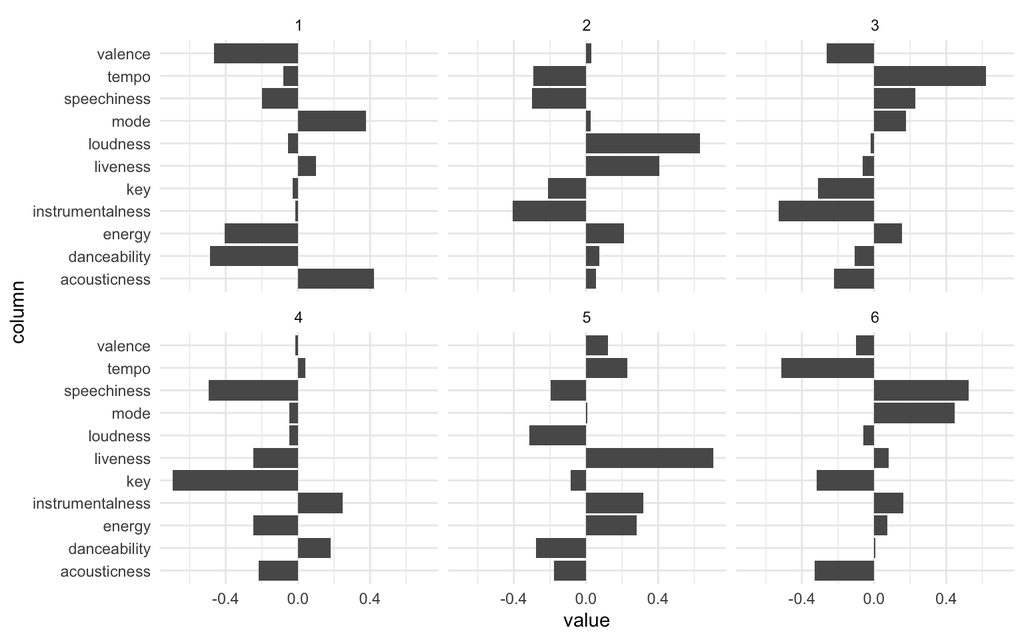

```r
# Visualise the first 6 components:
tidy(Spice_PCA, matrix = "loadings") %>%
  filter(PC <= 6) %>%
  ggplot(aes(value, column))+
  facet_wrap(~ PC)+
  geom_col()
```

Finally, by specifying matrix = “eigenvalues” we can get the explained standard deviation for each PC including a percent and cumulative:

```r
tidy(Spice_PCA, matrix = "eigenvalues")
```

```
## # A tibble: 11 × 4
##       PC std.dev percent cumulative
##    <dbl>   <dbl>   <dbl>      <dbl>
##  1     1   1.72   0.268       0.268
##  2     2   1.35   0.166       0.435
##  3     3   1.16   0.122       0.557
##  4     4   1.09   0.108       0.664
##  5     5   0.990  0.0891      0.754
##  6     6   0.852  0.066       0.820
##  7     7   0.831  0.0627      0.882
##  8     8   0.695  0.0439      0.926
##  9     9   0.636  0.0368      0.963
## 10    10   0.497  0.0224      0.985
## 11    11   0.401  0.0146      1
```

And we can plot the results:

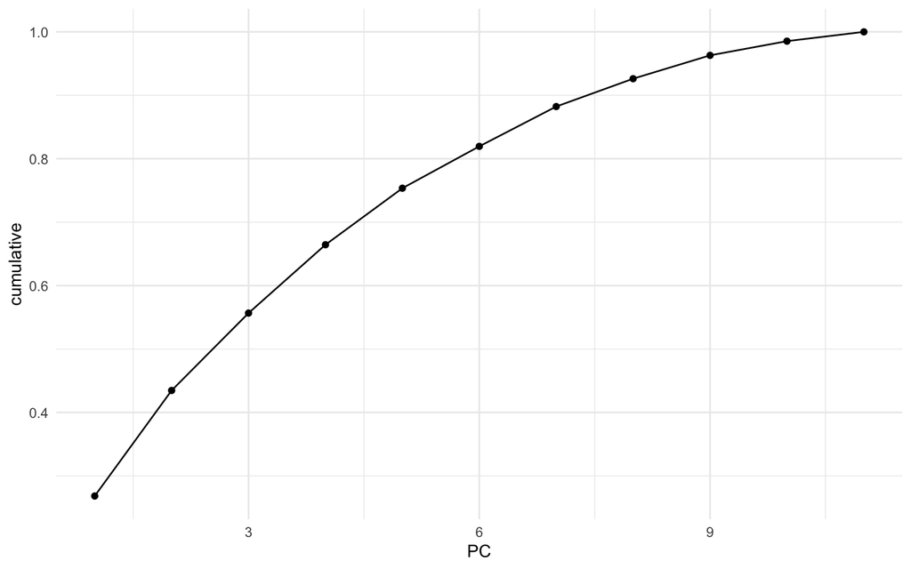

```r
tidy(Spice_PCA, matrix = "eigenvalues") %>%
  ggplot(aes(PC, cumulative)) +
  geom_point()+
  geom_line()
```

The augment() function will return the fitted PC transformation if we apply it to the prcomp() object directly:

```r
augment(Spice_PCA)
```

```
## # A tibble: 31 × 12
##    .rownames   .fittedPC1 .fittedPC2 .fittedPC3 .fittedPC4 .fittedPC5 .fittedPC6
##    <chr>            <dbl>      <dbl>      <dbl>      <dbl>      <dbl>      <dbl>
##  1 Holler          -1.81       0.571    -0.502      -0.548    -0.899     -0.755
##  2 Tell Me Why     -2.01       0.868    -0.439       0.589    -1.19      -0.310
##  3 Let Love L…      0.968      0.240     0.123      -0.868    -0.150     -0.436
##  4 Right Back…     -0.215      0.450     0.0387     -0.196    -0.616      0.563
##  5 Get Down W…     -1.85       0.848    -0.0599      1.72     -1.16      -0.213
##  6 Wasting My…     -1.62       0.813    -0.234       0.287    -0.438     -0.0526
##  7 Weekend Lo…      1.10       2.26      0.332       0.748    -0.121      0.660
##  8 Time Goes …      3.11       0.643     0.195       1.69     -0.861      1.02
##  9 If You Wan…     -1.16       2.05     -0.728      -0.901    -0.0990    -0.708
## 10 Oxygen           3.80       0.126    -1.42       -1.15     -1.81      -1.20
## # … with 21 more rows, and 5 more variables: .fittedPC7 <dbl>,
## #   .fittedPC8 <dbl>, .fittedPC9 <dbl>, .fittedPC10 <dbl>, .fittedPC11 <dbl>
```

We can apply the transformation to new data by passing the new data to the newdata parameter:

```r
augment(Spice_PCA, newdata = Spice_tracks[1:5,])
```

```
## # A tibble: 5 × 23
##   .rownames    danceability energy   key loudness  mode speechiness acousticness
##   <chr>               <dbl>  <dbl> <dbl>    <dbl> <dbl>       <dbl>        <dbl>
## 1 Holler              0.769  0.819    10    -3.94     0      0.0431      0.0293
## 2 Tell Me Why         0.829  0.764     5    -3.78     0      0.0431      0.0287
## 3 Let Love Le…        0.614  0.788    11    -5.55     1      0.027       0.155
## 4 Right Back …        0.736  0.779     8    -5.16     1      0.0401      0.0172
## 5 Get Down Wi…        0.86   0.71      1    -4.21     0      0.0356      0.00259
## # … with 15 more variables: instrumentalness <dbl>, liveness <dbl>,
## #   valence <dbl>, tempo <dbl>, .fittedPC1 <dbl>, .fittedPC2 <dbl>,
## #   .fittedPC3 <dbl>, .fittedPC4 <dbl>, .fittedPC5 <dbl>, .fittedPC6 <dbl>,
## #   .fittedPC7 <dbl>, .fittedPC8 <dbl>, .fittedPC9 <dbl>, .fittedPC10 <dbl>,
## #   .fittedPC11 <dbl>
```

## Tidymodels:

We can incorporate PCA into the tidymodels framework. The following recipe normalises the data and an id is set for future tidying:

```r
pca_rec <- recipe(~., data = Spice_tracks) %>%
  step_normalize(all_numeric()) %>%
  step_pca(all_numeric(), id= "pca") %>%
  prep()
```

We can call the bake() function to get the fitted PC transformation of the numeric variables:

```r
pca_rec %>%
  bake(new_data = NULL)
```

```
## # A tibble: 31 × 5
##       PC1   PC2     PC3    PC4     PC5
##     <dbl> <dbl>   <dbl>  <dbl>   <dbl>
##  1 -1.81  0.571 -0.502  -0.548 -0.899
##  2 -2.01  0.868 -0.439   0.589 -1.19
##  3  0.968 0.240  0.123  -0.868 -0.150
##  4 -0.215 0.450  0.0387 -0.196 -0.616
##  5 -1.85  0.848 -0.0599  1.72  -1.16
##  6 -1.62  0.813 -0.234   0.287 -0.438
##  7  1.10  2.26   0.332   0.748 -0.121
##  8  3.11  0.643  0.195   1.69  -0.861
##  9 -1.16  2.05  -0.728  -0.901 -0.0990
## 10  3.80  0.126 -1.42   -1.15  -1.81
## # … with 21 more rows
```

It can also be applied to new_data:

```r
pca_rec %>%
  bake(new_data= Spice_tracks[10:31,])
```

```
## # A tibble: 22 × 5
##       PC1     PC2     PC3    PC4    PC5
##     <dbl>   <dbl>   <dbl>  <dbl>  <dbl>
##  1  3.80   0.126  -1.42   -1.15  -1.81
##  2  1.38   0.451   1.22    0.719 -0.227
##  3 -0.411  1.54    1.27   -0.135  2.06
##  4 -1.25   0.868   0.0955  0.796 -0.485
##  5  3.63   1.22   -0.187  -0.455  0.181
##  6 -0.296 -2.30    1.08   -0.820 -0.274
##  7 -1.42   0.489   0.303   0.253  0.221
##  8 -1.72   0.0157  0.604  -1.32  -0.603
##  9 -1.19   0.925  -0.874  -1.20   0.682
## 10 -0.187 -1.84    2.39   -0.786 -0.109
## # … with 12 more rows
```

```r
tidy(pca_rec, id="pca", type="coef")
```

```
## # A tibble: 121 × 4
##    terms              value component id
##    <chr>              <dbl> <chr>     <chr>
##  1 danceability     -0.488  PC1       pca
##  2 energy           -0.405  PC1       pca
##  3 key              -0.0309 PC1       pca
##  4 loudness         -0.0565 PC1       pca
##  5 mode              0.377  PC1       pca
##  6 speechiness      -0.200  PC1       pca
##  7 acousticness      0.421  PC1       pca
##  8 instrumentalness -0.0138 PC1       pca
##  9 liveness          0.102  PC1       pca
## 10 valence          -0.466  PC1       pca
## # … with 111 more rows
```

As well as the eigenvalues:

```r
tidy(pca_rec, id="pca", type="variance")
```

```
## # A tibble: 44 × 4
##    terms    value component id
##    <chr>    <dbl>     <int> <chr>
##  1 variance 2.95          1 pca
##  2 variance 1.83          2 pca
##  3 variance 1.34          3 pca
##  4 variance 1.19          4 pca
##  5 variance 0.980         5 pca
##  6 variance 0.726         6 pca
##  7 variance 0.690         7 pca
##  8 variance 0.483         8 pca
##  9 variance 0.405         9 pca
## 10 variance 0.247        10 pca
## # … with 34 more rows
```

There will be times when we do not want all the principal components of the data, the number of components can be specified with num_comp:

```r
# For num_comp:
recipe(~., data = Spice_tracks) %>%
  step_normalize(all_numeric()) %>%
  step_pca(all_numeric(), num_comp = 3) %>%
  prep()
```

```
## Recipe
##
## Inputs:
##
##       role #variables
##  predictor         11
##
## Training data contained 31 data points and no missing data.
##
## Operations:
##
## Centering and scaling for danceability, energy, key, loudness, mode, spee... [trained]
## PCA extraction with danceability, energy, key, loudness, mode, speec... [trained]
```

Alternatively we can specify a threshold that determines how many components to keep by the amount of variance they explain. By setting the threshold = 0.7, step_pca() will generate eneough PCAs to explain 70% of the variance:

```r
# For threshold:
recipe(~., data = Spice_tracks) %>%
  step_normalize(all_numeric()) %>%
  step_pca(all_numeric(), threshold = .7) %>%
  prep()
```

```
## Recipe
##
## Inputs:
##
##       role #variables
##  predictor         11
##
## Training data contained 31 data points and no missing data.
##
## Operations:
##
## Centering and scaling for danceability, energy, key, loudness, mode, spee... [trained]
## PCA extraction with danceability, energy, key, loudness, mode, speec... [trained]
```

# Clustering

## Kmeans Clustering:

Kmeans clustering can be performed on the data by using the funciton kmeans(). We can begin by trying a number of different values for k and then select the best one. Multiple models can be fitted with the map() and mutate() functions:

```r
set.seed(1234)
multi_kmeans <- multi_kmeans <- tibble(k = 1:10) %>%
  mutate(
    model = purrr::map(k, ~ kmeans(Spice_tracks, centers = .x, nstart = 20)),
    tot.withinss = purrr::map_dbl(model, ~ glance(.x)$tot.withinss)
  )

multi_kmeans
```

```
## # A tibble: 10 × 3
##        k model    tot.withinss
##    <int> <list>          <dbl>
##  1     1 <kmeans>       22549.
##  2     2 <kmeans>        6413.
##  3     3 <kmeans>        3649.
##  4     4 <kmeans>        1949.
##  5     5 <kmeans>        1461.
##  6     6 <kmeans>        1016.
##  7     7 <kmeans>         829.
##  8     8 <kmeans>         720.
##  9     9 <kmeans>         616.
## 10    10 <kmeans>         505.
```

Given that we now have the total within cluster sum of squares, they can be plotted against k so we can use the elbow method to find the optimal number of clusters:

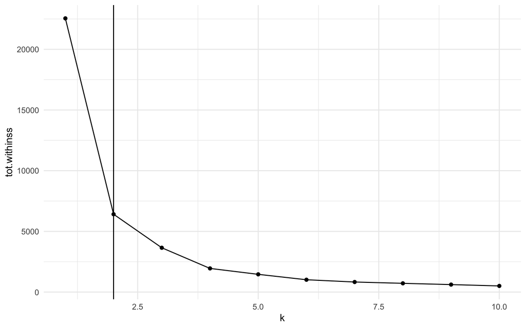

```r
multi_kmeans %>%
  ggplot(aes(k, tot.withinss))+
  geom_point()+
  geom_line()+
  geom_vline(xintercept = 2)
```

The elbow can be seen at k = 2, as marked by the x-intercept. As such we can now extract the model where k = 2 from multi_means:

```r
final_kmeans <- multi_kmeans %>%
  filter(k == 2) %>%
  pull(model) %>%
  pluck(1)
```

The clusters can be visualised as follows:

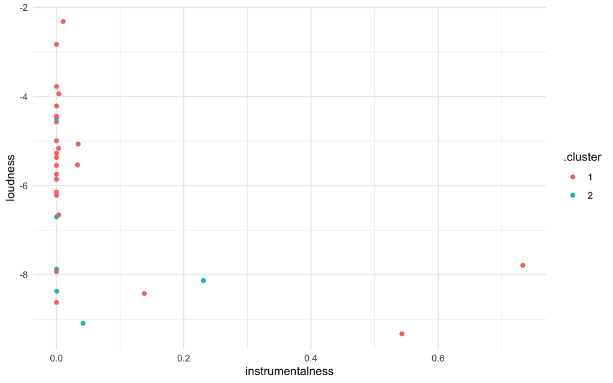

```r
augment(final_kmeans, data = Spice_tracks) %>%
  ggplot(aes(instrumentalness, loudness, color = .cluster)) +
  # The variables being plotted can be modified as per the analysis of interest
  geom_point()
```

## Hierachical Clustering

The hclust() function provides a convenient way to perform hierarchical clustering in R. This function only requires one input, which is a dissimilarity structure, that can be produced using the dist() function. This method enables the specification of the agglomeration method. Below are a few ways to cluster the data:

```r
res_hclust_complete <- Spice_tracks %>%
  dist() %>%
  hclust(method = "complete")

res_hclust_average <- Spice_tracks %>%
  dist() %>%
  hclust(method = "average")

res_hclust_single <- Spice_tracks %>%
  dist() %>%
  hclust(method = "single")
```

Th clustering can be visualised using the fviz_dend() function from the factoextra package.

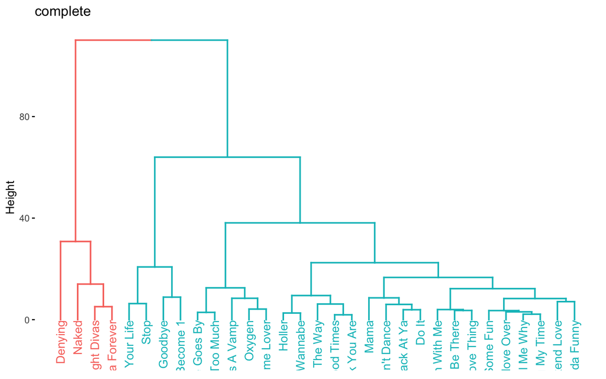

```r
fviz_dend(res_hclust_complete, main = "complete", k = 2)
```

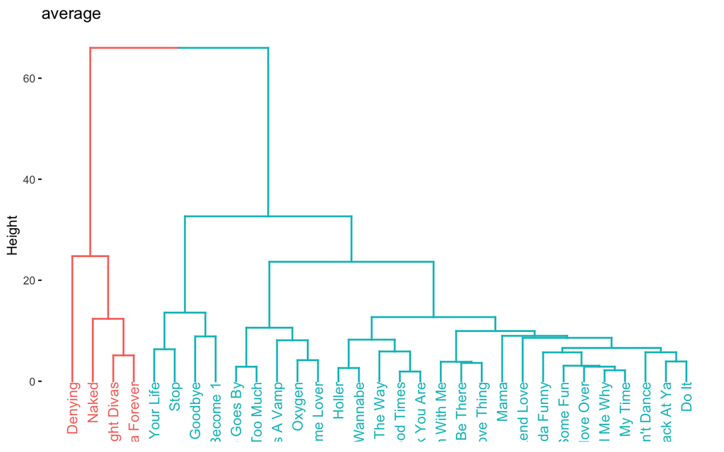

```r
fviz_dend(res_hclust_average, main = "average", k = 2)
```

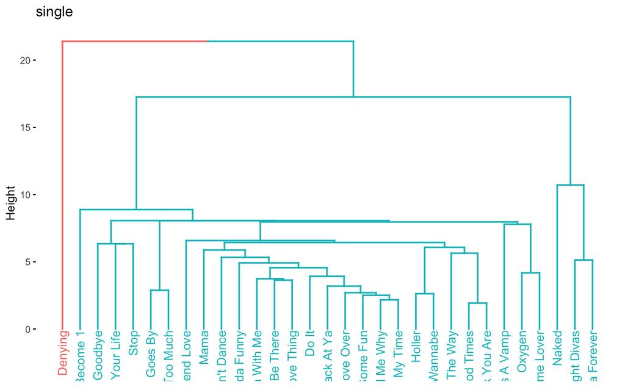

```r
fviz_dend(res_hclust_single, main = "single", k = 2)
```

If the importance of the different predictors in a data set is not known, it would be beneficial to scale the data such that the influence of each variable is equal:

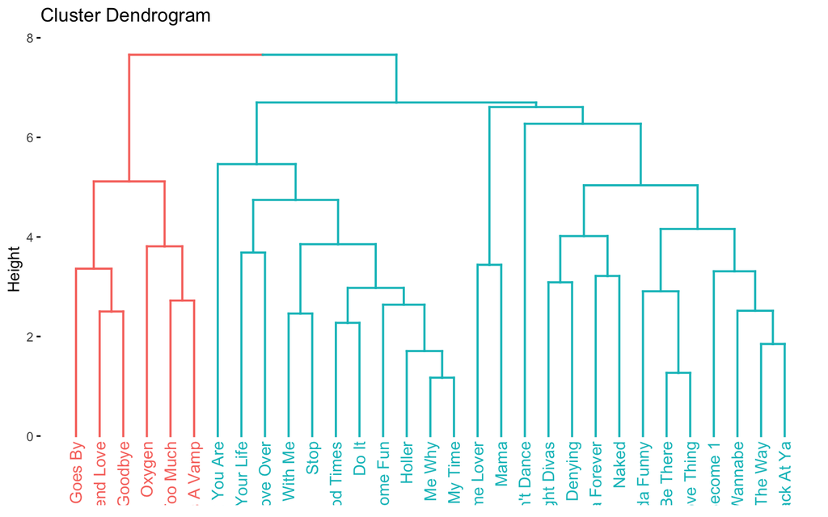

```r
  Spice_tracks %>%
  scale() %>%
  dist() %>%
  hclust(method = "complete") %>%
  fviz_dend(k = 2)
```

An alternative distance calculation method is based on correlation:

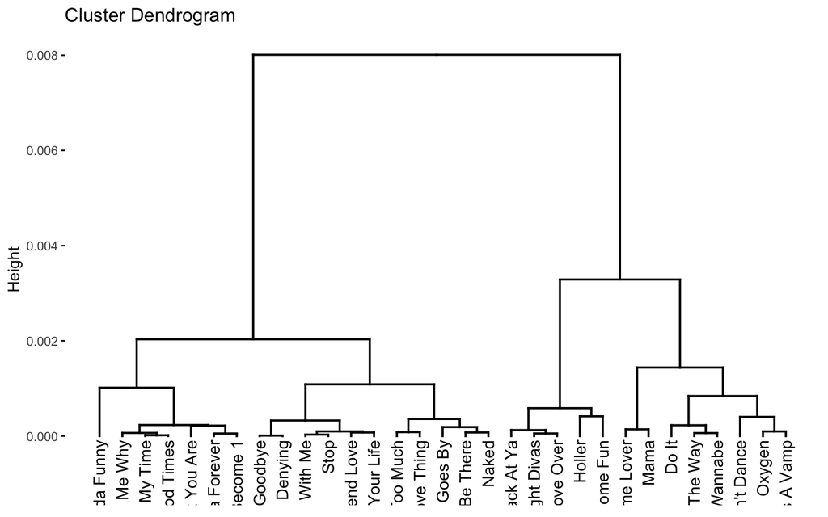

```r
set.seed(1234)
Spice_tracks %>%
  dist(method = "correlation") %>%
  hclust(method = "complete") %>%
  fviz_dend()
```